tcc | mudanças climáticas e inadimplência

# Dinâmica temporal e desastres climáticos

SARIMA × SARIMAX • Brasil, 2013–2024 • análise concluída com ressalvas

## Objetivo e desenho

A pergunta é se os desastres climáticos acrescentam informação à variação mensal da inadimplência brasileira além de sua dinâmica própria. Comparação por BIC e previsões um mês à frente: SARIMA sem clima versus SARIMAX com o mesmo componente autorregressivo e um regressor climático por vez. Amostra: Brasil, janeiro de 2013 a dezembro de 2024. A avaliação é observacional.

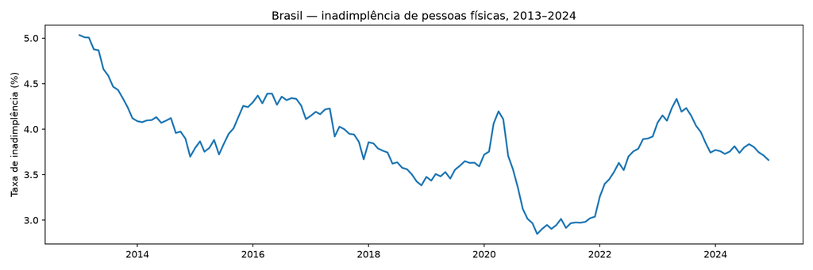

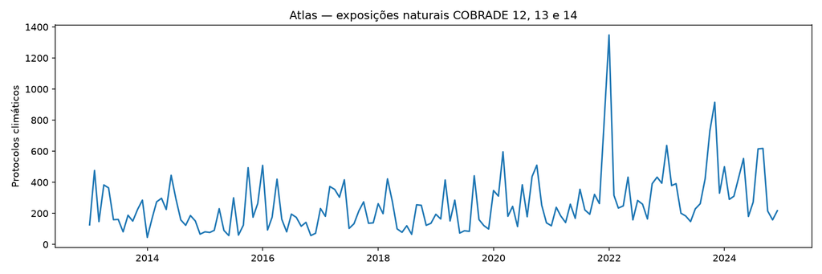

## Dados e estacionariedade

Taxa nacional I=100×Σ carteira inadimplente/Σ carteira ativa. Resposta y=100×Δlog(I). Exposição x=Δlog(1+D). Diferenciação externa uma vez, d=D=0 dentro de SARIMAX. ADF testa raiz unitária; KPSS testa estacionariedade. No pré-pandemia a conclusão para y é inconclusiva.

| periodo | variavel | transformacao | adf_p | kpss_p |
| --- | --- | --- | --- | --- |
| total | I | nível | 0.1958 | 0.017 |
| total | I | primeira diferença | 0.0208 | 0.100 |
| total | Clima \| Protocolos | nível | 0.5060 | 0.010 |
| total | Clima \| Protocolos | primeira diferença | 0.0000 | 0.100 |
| pré-pandemia | I | nível | 0.1221 | 0.010 |
| pré-pandemia | I | primeira diferença | 0.3429 | 0.100 |
| pré-pandemia | Clima \| Protocolos | nível | 0.0017 | 0.100 |
| pré-pandemia | Clima \| Protocolos | primeira diferença | 0.0000 | 0.100 |

## Escolha parcimoniosa e diagnóstico

A autocorrelação nos lags 3 e 6 dos ensaios anteriores motivou duas estruturas simples adicionais. A seleção entre candidatas foi feita só no treino, considerando BIC e Ljung–Box ajustado pelas ordens ARMA (lags 12 e 24). A alternativa anual esparsa preserva s=12; a alternativa semestral usa componente s=6 e harmônicos anuais previsíveis. A referência com harmônicos anuais é tecnicamente uma regressão determinística com erros SARIMA, e não um SARIMA puramente univariado. O cenário sem clima escolhido é mantido ao adicionar um desastre, comparando o ganho incremental de forma consistente. Não foram escolhidos parâmetros com dados do teste.

| periodo | especificacao | ordem | sazonal | controles | n_treino | bic | aic | n | n_param_ar_ma | lb6_sem_ajuste_p | lb12_ajustado_p | lb24_ajustado_p | arch3_p | jarque_bera_p | residuos_ok |
| --- | --- | --- | --- | --- | --- | --- | --- | --- | --- | --- | --- | --- | --- | --- | --- |
| total | semestral_fourier | (1, 0, 0) | (1, 0, 0, 6) | sin_ano+cos_ano | 116 | 550.8255 | 534.3039 | 116 | 2 | 0.2236 | 0.1827 | 0.4989 | 0.0000 | 0.0000 | True |
| pré-pandemia | esparso_1_6 | ([1, 6], 0, 0) | (0, 0, 0, 12) | nenhum | 81 | 347.9981 | 338.4203 | 81 | 2 | 0.1811 | 0.1543 | 0.2281 | 0.9665 | 0.3616 | True |

**Triagem dos modelos de referência**

| periodo | especificacao | ordem | sazonal | controles | bic | aic | status | n | n_param_ar_ma | lb6_sem_ajuste_p | lb12_ajustado_p | lb24_ajustado_p | arch3_p | jarque_bera_p | residuos_ok |
| --- | --- | --- | --- | --- | --- | --- | --- | --- | --- | --- | --- | --- | --- | --- | --- |
| total | anual_esparso | ([1, 3, 6], 0, 0) | (1, 0, 0, 12) | nenhum | 553.7072 | 537.1856 | ok | 116 | 4 | 0.1995 | 0.0823 | 0.1089 | 0.0032 | 0.0000 | True |
| total | semestral_fourier | (1, 0, 0) | (1, 0, 0, 6) | sin_ano+cos_ano | 550.8255 | 534.3039 | ok | 116 | 2 | 0.2236 | 0.1827 | 0.4989 | 0.0000 | 0.0000 | True |
| pré-pandemia | esparso_1_6 | ([1, 6], 0, 0) | (0, 0, 0, 12) | nenhum | 347.9981 | 338.4203 | ok | 81 | 2 | 0.1811 | 0.1543 | 0.2281 | 0.9665 | 0.3616 | True |
| pré-pandemia | semianual_ar | (1, 0, 0) | (1, 0, 0, 6) | nenhum | 348.0235 | 338.4457 | ok | 81 | 2 | 0.3059 | 0.2785 | 0.3958 | 0.9837 | 0.3588 | True |

## SARIMA versus SARIMAX

Os modelos com desastres usam uma exposição e um lag (0, 1 ou 3 meses), escolhidos no treino pelo BIC entre candidatos com resíduo adequado, quando disponíveis. A coluna ΔBIC é a diferença em relação à referência sem clima no mesmo período. ΔBIC negativo favorece a inclusão do desastre; valor positivo favorece o modelo sem clima.

| periodo | categoria | lag | especificacao | bic_treino | aic_treino | delta_bic | n | n_param_ar_ma | lb6_sem_ajuste_p | lb12_ajustado_p | lb24_ajustado_p | arch3_p | jarque_bera_p | residuos_ok |
| --- | --- | --- | --- | --- | --- | --- | --- | --- | --- | --- | --- | --- | --- | --- |
| total | SARIMA | NaN | semestral_fourier | 550.8255 | 534.3039 | 0.0000 | 116 | 2 | 0.2236 | 0.1827 | 0.4989 | 0.0000 | 0.0000 | True |
| total | Clima \| Protocolos | 0.0 | semestral_fourier | 553.3359 | 534.0608 | 2.5105 | 116 | 2 | 0.2267 | 0.1132 | 0.4015 | 0.0000 | 0.0000 | True |
| total | Tipologia \| Alagamentos | 1.0 | semestral_fourier | 554.8425 | 535.5673 | 4.0170 | 116 | 2 | 0.2105 | 0.1439 | 0.3954 | 0.0000 | 0.0000 | True |
| total | Tipologia \| Chuvas Intensas | 1.0 | semestral_fourier | 552.3215 | 533.0464 | 1.4960 | 116 | 2 | 0.1469 | 0.1087 | 0.3373 | 0.0000 | 0.0000 | True |
| total | Tipologia \| Enxurradas | 1.0 | semestral_fourier | 552.0848 | 532.8097 | 1.2594 | 116 | 2 | 0.1821 | 0.1754 | 0.5730 | 0.0000 | 0.0000 | True |
| total | Tipologia \| Estiagem e Seca | 0.0 | semestral_fourier | 554.2571 | 534.9819 | 3.4316 | 116 | 2 | 0.2023 | 0.1349 | 0.4031 | 0.0001 | 0.0000 | True |
| total | Tipologia \| Granizo | 3.0 | semestral_fourier | 551.9997 | 532.7246 | 1.1742 | 116 | 2 | 0.2071 | 0.1976 | 0.4072 | 0.0000 | 0.0000 | True |
| total | Tipologia \| Incêndio Florestal | 0.0 | semestral_fourier | 554.2239 | 534.9487 | 3.3984 | 116 | 2 | 0.1896 | 0.1957 | 0.4934 | 0.0000 | 0.0000 | True |
| total | Tipologia \| Inundações | 0.0 | semestral_fourier | 554.1320 | 534.8568 | 3.3065 | 116 | 2 | 0.2359 | 0.1350 | 0.4157 | 0.0000 | 0.0000 | True |
| total | Tipologia \| Onda de Calor e Baixa Umidade | 1.0 | semestral_fourier | 554.8082 | 535.5331 | 3.9827 | 116 | 2 | 0.1706 | 0.1581 | 0.4675 | 0.0000 | 0.0001 | True |
| total | Tipologia \| Onda de Frio | 3.0 | semestral_fourier | 555.2931 | 536.0179 | 4.4676 | 116 | 2 | 0.2153 | 0.1765 | 0.4779 | 0.0000 | 0.0000 | True |
| total | Tipologia \| Tornado | 0.0 | semestral_fourier | 553.9257 | 534.6505 | 3.1002 | 116 | 2 | 0.2375 | 0.2759 | 0.5967 | 0.0000 | 0.0000 | True |
| total | Tipologia \| Vendavais e Ciclones | 0.0 | semestral_fourier | 555.1816 | 535.9065 | 4.3561 | 116 | 2 | 0.2273 | 0.1496 | 0.4639 | 0.0000 | 0.0000 | True |
| pré-pandemia | SARIMA | NaN | esparso_1_6 | 347.9981 | 338.4203 | 0.0000 | 81 | 2 | 0.1811 | 0.1543 | 0.2281 | 0.9665 | 0.3616 | True |
| pré-pandemia | Clima \| Protocolos | 0.0 | esparso_1_6 | 348.8455 | 336.8732 | 0.8473 | 81 | 2 | 0.1293 | 0.0758 | 0.1462 | 0.8416 | 0.5419 | True |
| pré-pandemia | Tipologia \| Alagamentos | 3.0 | esparso_1_6 | 349.0631 | 337.0909 | 1.0650 | 81 | 2 | 0.0998 | 0.0909 | 0.0970 | 0.9689 | 0.1950 | True |
| pré-pandemia | Tipologia \| Chuvas Intensas | 1.0 | esparso_1_6 | 350.9187 | 338.9464 | 2.9205 | 81 | 2 | 0.0765 | 0.0505 | 0.1075 | 0.9370 | 0.2833 | True |
| pré-pandemia | Tipologia \| Enxurradas | 1.0 | esparso_1_6 | 350.2909 | 338.3186 | 2.2927 | 81 | 2 | 0.0716 | 0.0525 | 0.0778 | 0.9232 | 0.2003 | True |
| pré-pandemia | Tipologia \| Estiagem e Seca | 1.0 | esparso_1_6 | 348.9855 | 337.0132 | 0.9873 | 81 | 2 | 0.2446 | 0.2903 | 0.3718 | 0.9954 | 0.8653 | True |
| pré-pandemia | Tipologia \| Granizo | 1.0 | esparso_1_6 | 348.5410 | 336.5688 | 0.5429 | 81 | 2 | 0.1334 | 0.1151 | 0.1027 | 0.9301 | 0.5259 | True |
| pré-pandemia | Tipologia \| Incêndio Florestal | 0.0 | esparso_1_6 | 350.1128 | 338.1406 | 2.1147 | 81 | 2 | 0.1792 | 0.2333 | 0.3948 | 0.9147 | 0.2697 | True |
| pré-pandemia | Tipologia \| Inundações | 3.0 | esparso_1_6 | 350.4902 | 338.5179 | 2.4920 | 81 | 2 | 0.1843 | 0.2102 | 0.2365 | 0.9173 | 0.4544 | True |
| pré-pandemia | Tipologia \| Tornado | 0.0 | esparso_1_6 | 351.3237 | 339.3515 | 3.3256 | 81 | 2 | 0.2107 | 0.1851 | 0.2246 | 0.8471 | 0.4130 | True |
| pré-pandemia | Tipologia \| Vendavais e Ciclones | 1.0 | esparso_1_6 | 350.7249 | 338.7527 | 2.7268 | 81 | 2 | 0.1356 | 0.1296 | 0.1866 | 0.9929 | 0.3850 | True |

## Coeficientes e multiplicidade

Coeficientes na escala de 100×Δlog(I) por unidade de Δlog(1+D), com intervalos de confiança de 95%. Não correspondem a pontos percentuais da taxa nem à causalidade. BH separa as famílias de hipóteses do período completo e do pré-pandemia; p e q permanecem condicionais à especificação escolhida. Resultados dos coeficientes são do reajuste sobre toda a janela, após a avaliação temporal.

| periodo | categoria | lag | n | beta | erro_padrao | ic95_inf | ic95_sup | p | residuos_ok_treino | q_bh |
| --- | --- | --- | --- | --- | --- | --- | --- | --- | --- | --- |
| total | Clima \| Protocolos | 0 | 140 | 0.3657 | 0.2468 | -0.1181 | 0.8495 | 0.1384 | True | 0.2888 |
| total | Tipologia \| Alagamentos | 1 | 140 | -0.1812 | 0.1995 | -0.5721 | 0.2098 | 0.3638 | True | 0.5457 |
| total | Tipologia \| Chuvas Intensas | 1 | 140 | -0.2713 | 0.1538 | -0.5726 | 0.0301 | 0.0777 | True | 0.2888 |
| total | Tipologia \| Enxurradas | 1 | 140 | -0.2040 | 0.1327 | -0.4640 | 0.0560 | 0.1242 | True | 0.2888 |
| total | Tipologia \| Estiagem e Seca | 0 | 140 | 0.2076 | 0.1422 | -0.0712 | 0.4864 | 0.1444 | True | 0.2888 |
| total | Tipologia \| Granizo | 3 | 140 | 0.1767 | 0.1133 | -0.0454 | 0.3988 | 0.1189 | True | 0.2888 |
| total | Tipologia \| Incêndio Florestal | 0 | 140 | 0.0726 | 0.1735 | -0.2676 | 0.4127 | 0.6759 | True | 0.7373 |
| total | Tipologia \| Inundações | 0 | 140 | 0.1174 | 0.1530 | -0.1825 | 0.4174 | 0.4428 | True | 0.5904 |
| total | Tipologia \| Onda de Calor e Baixa Umidade | 1 | 140 | 0.4068 | 0.2440 | -0.0714 | 0.8849 | 0.0954 | True | 0.2888 |
| total | Tipologia \| Onda de Frio | 3 | 140 | -0.0441 | 0.2567 | -0.5472 | 0.4590 | 0.8637 | True | 0.8637 |
| total | Tipologia \| Tornado | 0 | 140 | -0.2760 | 0.2062 | -0.6802 | 0.1282 | 0.1808 | True | 0.3099 |
| total | Tipologia \| Vendavais e Ciclones | 0 | 140 | 0.1032 | 0.1577 | -0.2059 | 0.4123 | 0.5129 | True | 0.6155 |
| pré-pandemia | Clima \| Protocolos | 0 | 81 | 0.5321 | 0.2679 | 0.0071 | 1.0571 | 0.0470 | True | 0.1646 |
| pré-pandemia | Tipologia \| Alagamentos | 3 | 81 | 0.4123 | 0.2241 | -0.0270 | 0.8516 | 0.0658 | True | 0.1646 |
| pré-pandemia | Tipologia \| Chuvas Intensas | 1 | 81 | -0.1832 | 0.1551 | -0.4873 | 0.1209 | 0.2377 | True | 0.2642 |
| pré-pandemia | Tipologia \| Enxurradas | 1 | 81 | -0.2182 | 0.1462 | -0.5047 | 0.0683 | 0.1354 | True | 0.2257 |
| pré-pandemia | Tipologia \| Estiagem e Seca | 1 | 81 | 0.3784 | 0.1970 | -0.0077 | 0.7645 | 0.0547 | True | 0.1646 |
| pré-pandemia | Tipologia \| Granizo | 1 | 81 | -0.2330 | 0.1043 | -0.4375 | -0.0286 | 0.0255 | True | 0.1646 |
| pré-pandemia | Tipologia \| Incêndio Florestal | 0 | 81 | 0.2771 | 0.1848 | -0.0850 | 0.6392 | 0.1337 | True | 0.2257 |
| pré-pandemia | Tipologia \| Inundações | 3 | 81 | 0.2185 | 0.1672 | -0.1092 | 0.5462 | 0.1912 | True | 0.2642 |
| pré-pandemia | Tipologia \| Tornado | 0 | 81 | -0.2661 | 0.2759 | -0.8069 | 0.2746 | 0.3348 | True | 0.3348 |
| pré-pandemia | Tipologia \| Vendavais e Ciclones | 1 | 81 | -0.2419 | 0.2020 | -0.6379 | 0.1541 | 0.2311 | True | 0.2642 |

## Diagnósticos dos resíduos

Ljung–Box corrigido pelo número de parâmetros ARMA em 12 e 24 meses; Ljung–Box descritivo sem ajuste em 6 meses; ARCH(3) e Jarque–Bera. Não rejeitar Ljung–Box não prova independência, mas deixa de indicar dependência linear residual nos horizontes testados. Não usar q BH como correção pós-seleção.

| periodo | categoria | amostra | n | n_param_ar_ma | lb6_sem_ajuste_p | lb12_ajustado_p | lb24_ajustado_p | arch3_p | jarque_bera_p | residuos_ok |
| --- | --- | --- | --- | --- | --- | --- | --- | --- | --- | --- |
| total | SARIMA | treino | 116 | 2 | 0.2236 | 0.1827 | 0.4989 | 0.0000 | 0.0000 | True |
| total | SARIMA | completa | 140 | 2 | 0.1169 | 0.0234 | 0.0653 | 0.0000 | 0.0000 | False |
| total | Clima \| Protocolos | treino | 116 | 2 | 0.2267 | 0.1132 | 0.4015 | 0.0000 | 0.0000 | True |
| total | Clima \| Protocolos | completa | 140 | 2 | 0.1127 | 0.0114 | 0.0457 | 0.0000 | 0.0000 | False |
| total | Tipologia \| Alagamentos | treino | 116 | 2 | 0.2105 | 0.1439 | 0.3954 | 0.0000 | 0.0000 | True |
| total | Tipologia \| Alagamentos | completa | 140 | 2 | 0.0976 | 0.0152 | 0.0475 | 0.0000 | 0.0000 | False |
| total | Tipologia \| Chuvas Intensas | treino | 116 | 2 | 0.1469 | 0.1087 | 0.3373 | 0.0000 | 0.0000 | True |
| total | Tipologia \| Chuvas Intensas | completa | 140 | 2 | 0.0579 | 0.0112 | 0.0531 | 0.0000 | 0.0000 | False |
| total | Tipologia \| Enxurradas | treino | 116 | 2 | 0.1821 | 0.1754 | 0.5730 | 0.0000 | 0.0000 | True |
| total | Tipologia \| Enxurradas | completa | 140 | 2 | 0.0768 | 0.0216 | 0.1096 | 0.0000 | 0.0000 | False |
| total | Tipologia \| Estiagem e Seca | treino | 116 | 2 | 0.2023 | 0.1349 | 0.4031 | 0.0001 | 0.0000 | True |
| total | Tipologia \| Estiagem e Seca | completa | 140 | 2 | 0.1046 | 0.0155 | 0.0432 | 0.0000 | 0.0000 | False |
| total | Tipologia \| Granizo | treino | 116 | 2 | 0.2071 | 0.1976 | 0.4072 | 0.0000 | 0.0000 | True |
| total | Tipologia \| Granizo | completa | 140 | 2 | 0.1152 | 0.0337 | 0.0564 | 0.0000 | 0.0000 | False |
| total | Tipologia \| Incêndio Florestal | treino | 116 | 2 | 0.1896 | 0.1957 | 0.4934 | 0.0000 | 0.0000 | True |
| total | Tipologia \| Incêndio Florestal | completa | 140 | 2 | 0.1115 | 0.0229 | 0.0598 | 0.0000 | 0.0000 | False |
| total | Tipologia \| Inundações | treino | 116 | 2 | 0.2359 | 0.1350 | 0.4157 | 0.0000 | 0.0000 | True |
| total | Tipologia \| Inundações | completa | 140 | 2 | 0.1199 | 0.0187 | 0.0605 | 0.0000 | 0.0000 | False |
| total | Tipologia \| Onda de Calor e Baixa Umidade | treino | 116 | 2 | 0.1706 | 0.1581 | 0.4675 | 0.0000 | 0.0001 | True |
| total | Tipologia \| Onda de Calor e Baixa Umidade | completa | 140 | 2 | 0.0796 | 0.0290 | 0.1031 | 0.0000 | 0.0000 | False |
| total | Tipologia \| Onda de Frio | treino | 116 | 2 | 0.2153 | 0.1765 | 0.4779 | 0.0000 | 0.0000 | True |
| total | Tipologia \| Onda de Frio | completa | 140 | 2 | 0.1157 | 0.0245 | 0.0658 | 0.0000 | 0.0000 | False |
| total | Tipologia \| Tornado | treino | 116 | 2 | 0.2375 | 0.2759 | 0.5967 | 0.0000 | 0.0000 | True |
| total | Tipologia \| Tornado | completa | 140 | 2 | 0.1242 | 0.0433 | 0.0920 | 0.0000 | 0.0000 | False |
| total | Tipologia \| Vendavais e Ciclones | treino | 116 | 2 | 0.2273 | 0.1496 | 0.4639 | 0.0000 | 0.0000 | True |
| total | Tipologia \| Vendavais e Ciclones | completa | 140 | 2 | 0.1203 | 0.0182 | 0.0605 | 0.0000 | 0.0000 | False |
| pré-pandemia | SARIMA | treino | 81 | 2 | 0.1811 | 0.1543 | 0.2281 | 0.9665 | 0.3616 | True |
| pré-pandemia | Clima \| Protocolos | treino | 81 | 2 | 0.1293 | 0.0758 | 0.1462 | 0.8416 | 0.5419 | True |
| pré-pandemia | Clima \| Protocolos | completa | 81 | 2 | 0.1293 | 0.0758 | 0.1462 | 0.8416 | 0.5419 | True |
| pré-pandemia | Tipologia \| Alagamentos | treino | 81 | 2 | 0.0998 | 0.0909 | 0.0970 | 0.9689 | 0.1950 | True |
| pré-pandemia | Tipologia \| Alagamentos | completa | 81 | 2 | 0.0998 | 0.0909 | 0.0970 | 0.9689 | 0.1950 | True |
| pré-pandemia | Tipologia \| Chuvas Intensas | treino | 81 | 2 | 0.0765 | 0.0505 | 0.1075 | 0.9370 | 0.2833 | True |
| pré-pandemia | Tipologia \| Chuvas Intensas | completa | 81 | 2 | 0.0765 | 0.0505 | 0.1075 | 0.9370 | 0.2833 | True |
| pré-pandemia | Tipologia \| Enxurradas | treino | 81 | 2 | 0.0716 | 0.0525 | 0.0778 | 0.9232 | 0.2003 | True |
| pré-pandemia | Tipologia \| Enxurradas | completa | 81 | 2 | 0.0716 | 0.0525 | 0.0778 | 0.9232 | 0.2003 | True |
| pré-pandemia | Tipologia \| Estiagem e Seca | treino | 81 | 2 | 0.2446 | 0.2903 | 0.3718 | 0.9954 | 0.8653 | True |
| pré-pandemia | Tipologia \| Estiagem e Seca | completa | 81 | 2 | 0.2446 | 0.2903 | 0.3718 | 0.9954 | 0.8653 | True |
| pré-pandemia | Tipologia \| Granizo | treino | 81 | 2 | 0.1334 | 0.1151 | 0.1027 | 0.9301 | 0.5259 | True |
| pré-pandemia | Tipologia \| Granizo | completa | 81 | 2 | 0.1334 | 0.1151 | 0.1027 | 0.9301 | 0.5259 | True |
| pré-pandemia | Tipologia \| Incêndio Florestal | treino | 81 | 2 | 0.1792 | 0.2333 | 0.3948 | 0.9147 | 0.2697 | True |
| pré-pandemia | Tipologia \| Incêndio Florestal | completa | 81 | 2 | 0.1792 | 0.2333 | 0.3948 | 0.9147 | 0.2697 | True |
| pré-pandemia | Tipologia \| Inundações | treino | 81 | 2 | 0.1843 | 0.2102 | 0.2365 | 0.9173 | 0.4544 | True |
| pré-pandemia | Tipologia \| Inundações | completa | 81 | 2 | 0.1843 | 0.2102 | 0.2365 | 0.9173 | 0.4544 | True |
| pré-pandemia | Tipologia \| Tornado | treino | 81 | 2 | 0.2107 | 0.1851 | 0.2246 | 0.8471 | 0.4130 | True |
| pré-pandemia | Tipologia \| Tornado | completa | 81 | 2 | 0.2107 | 0.1851 | 0.2246 | 0.8471 | 0.4130 | True |
| pré-pandemia | Tipologia \| Vendavais e Ciclones | treino | 81 | 2 | 0.1356 | 0.1296 | 0.1866 | 0.9929 | 0.3850 | True |
| pré-pandemia | Tipologia \| Vendavais e Ciclones | completa | 81 | 2 | 0.1356 | 0.1296 | 0.1866 | 0.9929 | 0.3850 | True |

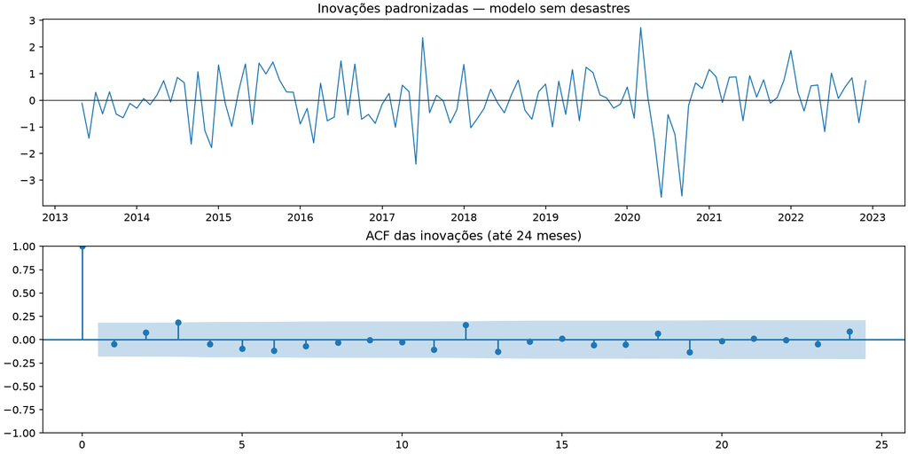

## Comparação preditiva 2023–2024

Jan/2023–dez/2024 é um teste cronológico não usado na escolha de especificações. 24 previsões um mês à frente, estado atualizado com a observação anterior e coeficientes fixos. O erro é medido em 100×Δlog(I). Diferenças muito pequenas não devem ser declaradas superioridade preditiva. Exposições de lag zero representam cenários condicionados aos desastres observados no mês previsto (não operacional).

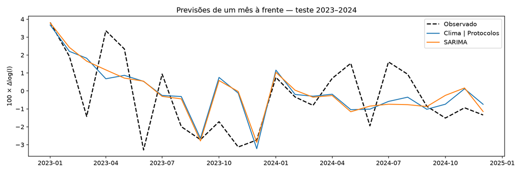

| periodo | categoria | lag | n_teste | mae | rmse | viez | tipo_previsao |
| --- | --- | --- | --- | --- | --- | --- | --- |
| total | SARIMA | NaN | 24 | 1.3385 | 1.7294 | -0.2554 | sem clima |
| total | Clima \| Protocolos | 0.0 | 24 | 1.3356 | 1.7260 | -0.2459 | condicional a D_t observado |
| total | Tipologia \| Alagamentos | 1.0 | 24 | 1.3248 | 1.7249 | -0.2464 | histórico climático defasado |
| total | Tipologia \| Chuvas Intensas | 1.0 | 24 | 1.2936 | 1.6927 | -0.2661 | histórico climático defasado |
| total | Tipologia \| Enxurradas | 1.0 | 24 | 1.4219 | 1.7888 | -0.2349 | histórico climático defasado |
| total | Tipologia \| Estiagem e Seca | 0.0 | 24 | 1.3352 | 1.7194 | -0.2495 | condicional a D_t observado |
| total | Tipologia \| Granizo | 3.0 | 24 | 1.4295 | 1.7898 | -0.2659 | histórico climático defasado |
| total | Tipologia \| Incêndio Florestal | 0.0 | 24 | 1.4347 | 1.8463 | -0.2662 | condicional a D_t observado |
| total | Tipologia \| Inundações | 0.0 | 24 | 1.4114 | 1.7872 | -0.2585 | condicional a D_t observado |
| total | Tipologia \| Onda de Calor e Baixa Umidade | 1.0 | 24 | 1.2502 | 1.6440 | -0.2363 | histórico climático defasado |
| total | Tipologia \| Onda de Frio | 3.0 | 24 | 1.3777 | 1.7533 | -0.2590 | histórico climático defasado |
| total | Tipologia \| Tornado | 0.0 | 24 | 1.3446 | 1.7220 | -0.2465 | condicional a D_t observado |
| total | Tipologia \| Vendavais e Ciclones | 0.0 | 24 | 1.3277 | 1.7224 | -0.2576 | condicional a D_t observado |

## Sensibilidade e suporte

A alternativa teórica anual (s=12 com lags AR 1,3,6) e a estrutura semestral com sazonalidade determinística anual são comparadas separadamente no total climático. O suporte de tipologias raras foi auditado no treino; grupos exatos COBRADE não podem ser reconstruídos a partir da tabela já agregada.

| especificacao | lag | bic_sem | bic_com | delta_bic | rmse_sem | rmse_com | delta_rmse | residuos_sem_ok | residuos_com_ok |
| --- | --- | --- | --- | --- | --- | --- | --- | --- | --- |
| anual_esparso | 0 | 553.7072 | 553.7998 | 0.0926 | 1.3773 | 1.4224 | 0.0451 | True | True |

| periodo | categoria | meses_positivos | registros | estimavel |
| --- | --- | --- | --- | --- |
| total | Clima \| Protocolos | 116 | 27322 | True |
| total | Tipologia \| Alagamentos | 111 | 1160 | True |
| total | Tipologia \| Chuvas Intensas | 114 | 5058 | True |
| total | Tipologia \| Enxurradas | 111 | 2261 | True |
| total | Tipologia \| Estiagem e Seca | 116 | 12623 | True |
| total | Tipologia \| Granizo | 92 | 834 | True |
| total | Tipologia \| Incêndio Florestal | 87 | 1496 | True |
| total | Tipologia \| Inundações | 106 | 1723 | True |
| total | Tipologia \| Onda de Calor e Baixa Umidade | 29 | 56 | True |
| total | Tipologia \| Onda de Frio | 29 | 183 | True |
| total | Tipologia \| Tornado | 33 | 57 | True |
| total | Tipologia \| Vendavais e Ciclones | 115 | 1871 | True |
| pré-pandemia | Clima \| Protocolos | 81 | 16057 | True |
| pré-pandemia | Tipologia \| Alagamentos | 77 | 670 | True |
| pré-pandemia | Tipologia \| Chuvas Intensas | 79 | 2133 | True |
| pré-pandemia | Tipologia \| Enxurradas | 77 | 1759 | True |
| pré-pandemia | Tipologia \| Estiagem e Seca | 81 | 8461 | True |
| pré-pandemia | Tipologia \| Granizo | 61 | 504 | True |
| pré-pandemia | Tipologia \| Incêndio Florestal | 56 | 443 | True |
| pré-pandemia | Tipologia \| Inundações | 74 | 991 | True |
| pré-pandemia | Tipologia \| Onda de Calor e Baixa Umidade | 14 | 19 | False |
| pré-pandemia | Tipologia \| Onda de Frio | 13 | 59 | False |
| pré-pandemia | Tipologia \| Tornado | 25 | 41 | True |
| pré-pandemia | Tipologia \| Vendavais e Ciclones | 80 | 977 | True |

## Conclusão comparativa

Modelo sem clima: BIC 550.825, MAE 1.338, RMSE 1.729. Com total climático: BIC 553.336, MAE 1.336, RMSE 1.726. ΔBIC=2.510; ΔMAE=-0.003; ΔRMSE=-0.003. Pela métrica RMSE, SARIMAX foi menor. Pela métrica BIC, SARIMA foi preferido. As diferenças são descritivas; não constituem prova de causalidade, nem melhora preditiva estatisticamente comprovada em 24 meses. A análise dos erros padronizados também aponta ARCH/assimetria de distribuição na referência e autocorrelação residual no reajuste climático completo; logo, os p-valores do reajuste são exploratórios e não têm validade confirmatória assegurada. O resultado de sensibilidade anual indica mudança no sinal do ganho de RMSE.

Interpretação restrita a associação temporal e previsão condicional. A agregação nacional não equivale ao painel com efeitos fixos das 27 UFs. O período pré-pandemia tem amostra reduzida e ADF/KPSS divergentes; modelos dinâmicos não permitem identificar causalidade de desastres.